# HW3 Markdown

Hasan Arcas

11/24/2021

### At the beginning of the project, I’ve imported the libraries that I’m are going to use

```r
library(ggplot2)
library(dplyr)
library(factoextra)
library(cluster)
library(datasets)
library(stats)
```

#### In addition I’ve colored each point representing an iris flower according to the specie it belongs to.

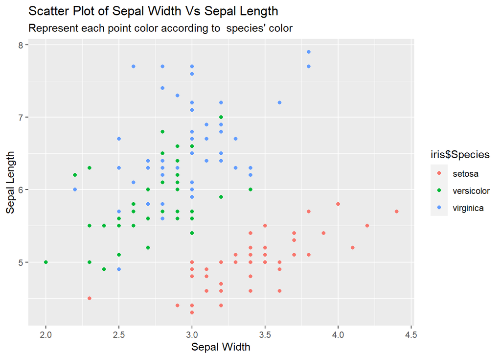

```r
ggplot(iris, mapping = aes(x = iris$Sepal.Width, y = iris$Sepal.Length, color = iris$Species))+
  geom_point() +
  labs(title = "Scatter Plot of Sepal Width Vs Sepal Length",
       subtitle = "Represent each point color according to  species' color",
       x = "Sepal Width",
       y = "Sepal Length")
```

### I’ve applied principal components to the ‘Iris’ dataset in order to see the potential number of clusters.

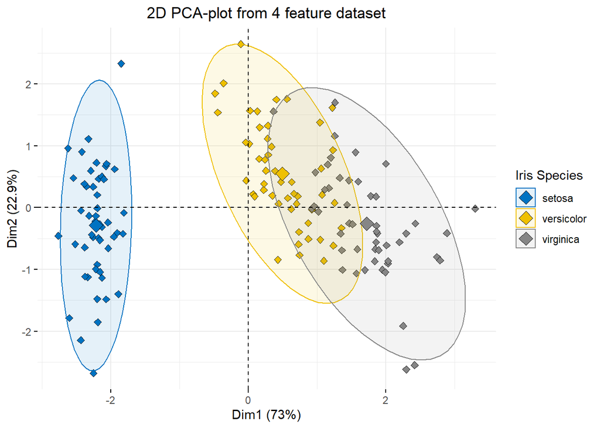

```r
iris_X <- iris[1:4]
iris_y <- iris[5]

pca <- prcomp(iris_X, scale= T, center = T)     # mantıksız oldugu icin iris datasetten devam ediyoruz

fviz_pca_ind(pca, geom.ind = "point", pointshape = 23,
             pointsize = 2,
             fill.ind = iris$Species,
             col.ind = "black",
             palette = "jco",
             addEllipses = TRUE,
             label = "var",
             col.var = "black",
             repel = TRUE,
             legend.title = "Iris Species") +
  ggtitle("2D PCA-plot from 4 feature dataset") +
  theme(plot.title = element_text(hjust = 0.5))
```

### I’ve applied K Means Clustering with 3 centers in orther to see if the machine can identify all the different groups properly

```r
set.seed(102)
iris_kmeans <- kmeans(iris_X, 3)        # We use 3 because we already know that there are 3 classes
iris_kmeans_clusters <- iris_kmeans$cluster
iris_kmeans_clusters <- iris_kmeans$cluster %>%
    replace( iris_kmeans_clusters == 1, "virginica") %>%
    replace( iris_kmeans_clusters == 2, "setosa") %>%
    replace( iris_kmeans_clusters == 3, "versicolor")


predicted_vs_true <- data.frame(iris_kmeans_clusters, iris_y)
names(predicted_vs_true) <- c("Predicted", "True Value")
predicted_vs_true$Final <- ifelse(as.factor(predicted_vs_true$Predicted) == as.factor(predicted_vs_true$`True Value`), T, F)
head(predicted_vs_true)
```

```
##   Predicted True Value Final
## 1    setosa     setosa  TRUE
## 2    setosa     setosa  TRUE
## 3    setosa     setosa  TRUE
## 4    setosa     setosa  TRUE
## 5    setosa     setosa  TRUE
## 6    setosa     setosa  TRUE
```

```r
sum(predicted_vs_true$Final, na.rm = T) / count(predicted_vs_true)
```

```
##           n
## 1 0.8933333
```

#### After taking a look at the ‘iris_kmeans_clusters’ vector I saw that each value was in the ‘1’ , ‘2’ or ‘3’ cluster so I decided to change their values in order to compare them with my original ‘species’ value and saw that the clustering algorithm has done a fairly good job: 89.3% of accuracy

### Finally I’ve done pretty much the same thing for Hierarchical Clustering

#### After applying the hiearchical clustering algorithm I plotted a Cluster Dendogram of my data in order to visualize it

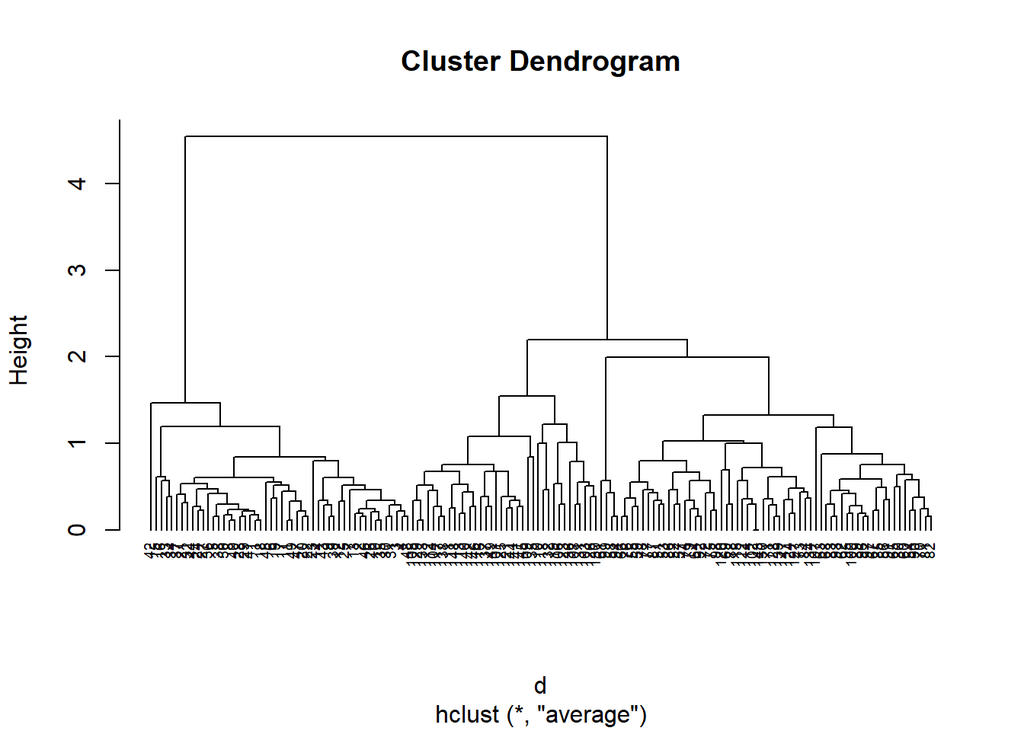

```r
d <- dist(iris, method = "euclidean")
hc <- hclust(d, method="average")
plot(hc, cex=0.6, hang=-1)
```

```r
hc_iris_predicted <- cutree(hc, k = 3, h = 3)
hc_iris_predicted <- cutree(hc, k = 3, h = 3) %>%
  replace(hc_iris_predicted == 1, "setosa") %>%
  replace(hc_iris_predicted == 2, "versicolor") %>%
  replace(hc_iris_predicted == 3, "virginica")


hc_predicted_vs_true <- data.frame(hc_iris_predicted, iris_y)
names(hc_predicted_vs_true) <- c("Predicted", "True Value")
hc_predicted_vs_true$final <- ifelse(as.factor(hc_predicted_vs_true$Predicted) == as.factor(hc_predicted_vs_true$`True Value`), T, F)

sum(hc_predicted_vs_true$final, na.rm = T) / count(hc_predicted_vs_true)
```

```
##           n
## 1 0.9066667
```

#### I saw that there was a slightly better performance with hierarchical clustering, the accuracy of our algorithm to identify the flower’s species, has rised from 89.3% to 90.7%